# Proyecto Final: Reporte Histórico ENVIPE

José Julián Martínez Feregrino, Carolina Hernández Camacho, Emmanuel Espejel Flores

2026-05-21

*“Detrás de cada dato existe una experiencia ciudadana; analizar la información sobre seguridad no solo permite comprender la delincuencia, sino también entender cómo transforma la confianza, la tranquilidad y la vida cotidiana de la sociedad.”*

## Introducción

La seguridad pública y la percepción de la delincuencia representan temas de gran importancia para la sociedad mexicana, ya que permiten conocer las condiciones en las que vive la población y el impacto que tienen los delitos en la vida cotidiana. Con el propósito de obtener información confiable sobre estos aspectos, el Instituto Nacional de Estadística y Geografía realiza anualmente la Encuesta Nacional de Victimización y Percepción sobre Seguridad Pública ENVIPE.

La ENVIPE es una encuesta diseñada para recopilar información relacionada con los delitos ocurridos en el país, la percepción de seguridad de la población, la confianza en las autoridades y las consecuencias económicas y sociales derivadas de la delincuencia. Su principal objetivo es generar estadísticas que permitan comprender la magnitud de la victimización en México, incluyendo aquellos delitos que no son denunciados ante las autoridades, fenómeno conocido como “cifra negra”.

El levantamiento de la encuesta se realiza cada año mediante entrevistas aplicadas directamente a personas mayores de 18 años en viviendas seleccionadas a nivel nacional. Posteriormente, los resultados son procesados y publicados por el INEGI un año después de la recolección de los datos. Por esta razón, en el presente reporte se analizan los resultados publicados entre 2021 y 2025, los cuales corresponden a la información recopilada durante los años 2020 a 2024.

El presente trabajo tiene como finalidad presentar y analizar diversas gráficas elaboradas a partir de datos obtenidos de la ENVIPE, con el propósito de identificar tendencias, cambios y comportamientos relacionados con la seguridad pública y la percepción ciudadana en México durante el periodo estudiado. Para ello, se seleccionaron 10 preguntas consideradas de interés por los autores del reporte, enfocadas en temas como percepción de inseguridad, incidencia delictiva, confianza en autoridades, medidas de protección adoptadas por la población y experiencias de victimización. Además, se buscó dar un enfoque orientado a comprender no solo la presencia de la delincuencia, sino también las consecuencias sociales y emocionales que esta genera en la población, tales como la desconfianza, el miedo, la percepción de vulnerabilidad y los cambios en la vida cotidiana de las personas.

De esta manera, cada pregunta fue analizada considerando cómo determinados factores pueden influir en la percepción de seguridad de la ciudadanía o evidenciar efectos provocados por la inseguridad, como la pérdida de confianza en el entorno, la preocupación constante por diferentes temas de interes social. Con ello, el presente trabajo busca ofrecer una interpretación más humana y social de los datos estadísticos presentados por la ENVIPE. A través del análisis gráfico de estos indicadores, se busca facilitar la interpretación de la información estadística y ofrecer una visión más clara de la evolución de la percepción y experiencia de la seguridad pública en México y más particularmente en Querétaro en los últimos años.

## Marco conceptual y antecedentes

La ENVIPE está dirigida a personas de 18 años o más que residen permanentemente en viviendas particulares dentro del territorio nacional. Sus resultados permiten conocer tanto los delitos denunciados como la cifra negra, lo que convierte a esta encuesta en una de las principales fuentes de información sobre seguridad pública en México.

El diseño estadístico de la encuesta es probabilístico, estratificado, trietápico y por conglomerados, lo que significa que la selección de viviendas y personas se realiza mediante procedimientos estadísticos que permiten extrapolar los resultados obtenidos hacia la población nacional. La unidad última de selección corresponde a la vivienda, mientras que las unidades de observación son los hogares y las personas mayores de edad que habitan en ellos.

Para construir la muestra, el INEGI utiliza el Marco Maestro de Muestreo elaborado con información cartográfica y demográfica proveniente del Censo de Población y Vivienda. A partir de este marco se forman las llamadas Unidades Primarias de Muestreo (UPM), integradas por agrupaciones de viviendas organizadas según características geográficas y demográficas. Dependiendo del tamaño poblacional y del tipo de localidad, estas unidades se clasifican en urbano alto, complemento urbano y rural. Posteriormente, las UPM se agrupan en distintos estratos sociodemográficos y geográficos para asegurar representatividad estadística en distintos niveles territoriales.

La cobertura geográfica de la ENVIPE permite generar resultados a nivel nacional, estatal y para determinadas áreas urbanas consideradas de interés estadístico. Sin embargo, la encuesta no está diseñada para producir estimaciones representativas para todos los municipios del país, ya que esto requeriría una muestra mucho mayor y un incremento considerable en los costos operativos y estadísticos.

**Áreas urbanas de interés y representatividad en Querétaro**

En el caso del estado de Querétaro, la información detallada y comparable únicamente puede obtenerse para los municipios de Querétaro, Corregidora y El Marqués. Esto ocurre porque dichos municipios forman parte de la principal zona metropolitana del estado, caracterizada por una alta concentración poblacional, continuidad urbana y fuerte integración económica y social. La expansión urbana de la ciudad de Querétaro ha generado un conglomerado urbano prácticamente continuo con Corregidora y El Marqués, convirtiéndolos en una sola área funcional para efectos estadísticos y metropolitanos.

La metodología de la ENVIPE prioriza precisamente este tipo de áreas metropolitanas debido a que concentran una gran proporción de la población y permiten construir muestras suficientemente amplias para obtener resultados confiables. Otro elemento fundamental para comprender esta delimitación es el uso de los factores de expansión. La ENVIPE cuenta con distintos factores estadísticos asociados a viviendas, hogares, personas y delitos, los cuales permiten extrapolar la información obtenida en la muestra hacia el total de la población. Además, existen factores especiales para las áreas urbanas de interés, identificados como FAC_VIV_AM, FAC_HOG_AM, FAC_ELE_AM y FAC_DEL_AM, construidos específicamente para aquellas ciudades o zonas metropolitanas donde el tamaño de muestra permite realizar estimaciones robustas.

En el caso de Querétaro, estos factores de expansión únicamente se calculan para la zona metropolitana integrada principalmente por Querétaro, Corregidora y El Marqués, debido a que en estos municipios existe una cantidad suficiente de viviendas seleccionadas y de Unidades Primarias de Muestreo. Gracias a ello, las estimaciones obtenidas pueden representar de manera adecuada el comportamiento real de la población.

Por el contrario, en otros municipios del estado no existe un factor de expansión municipal específico, ya que la muestra disponible no es lo suficientemente grande para garantizar precisión estadística. Aplicar factores de expansión en localidades con pocas viviendas encuestadas podría producir resultados sesgados o inestables que no representarían fielmente a la población real, aumentando significativamente el error de muestreo y reduciendo la confiabilidad de las estimaciones.

Por esta razón, el presente trabajo se enfoca en la información correspondiente a los municipios de Querétaro, Corregidora y El Marqués, ya que son los únicos que cuentan con datos estadísticamente representativos dentro del diseño oficial de la ENVIPE. A partir de esta información se busca analizar no solo la incidencia delictiva o la percepción de inseguridad, sino también las consecuencias sociales derivadas de la delincuencia, tales como la desconfianza, el miedo, la vulnerabilidad y los cambios en la relación de las personas con su entorno y comunidad.

## Estructura del reporte y análisis gráfico

Con el propósito de mantener una organización clara y facilitar la interpretación de la información obtenida de la ENVIPE, cada una de las preguntas seleccionadas en este reporte presenta una estructura de análisis común. Esta metodología permite comparar de manera uniforme los resultados obtenidos a nivel nacional, estatal y municipal durante el periodo 2020–2024.

Cada apartado incluye, en primer lugar, el planteamiento de la pregunta original utilizada en la encuesta, acompañado de una explicación general sobre el tema que aborda y las opciones de respuesta consideradas por la ENVIPE. Posteriormente, se presenta una sección titulada “¿Por qué es importante esta pregunta?”, en la cual se analiza la relevancia social de la información recopilada y la manera en que esta puede relacionarse con fenómenos como la percepción de inseguridad, la desconfianza ciudadana, la victimización o los efectos sociales de la delincuencia.

Después de la descripción conceptual de la pregunta, se incluyen gráficas históricas correspondientes al periodo 2020–2024 en tres distintos niveles de análisis:

- Nivel nacional (República Mexicana)
- Nivel estatal (Querétaro)
- Nivel municipal (Querétaro, Corregidora y El Marqués)

Estas gráficas permiten identificar tendencias, variaciones y diferencias en el comportamiento de los indicadores a través del tiempo y entre distintos contextos geográficos.

Asimismo, cada pregunta incorpora un breve análisis interpretativo de las gráficas presentadas, con el objetivo de describir los cambios más relevantes observados en los datos y su posible relación con la percepción de seguridad de la población.

Finalmente, se presenta una conclusión comparativa en la que se contrastan los resultados obtenidos en los tres niveles analizados —nacional, estatal y municipal—, buscando identificar similitudes, diferencias y comportamientos particulares que permitan comprender de mejor manera el impacto social de la inseguridad y la delincuencia en la población.

## Seccion de Preguntas

### Pregunta 1: Expectativas sobre la seguridad pública a nivel estado.

Esta pregunta analiza la percepción de la población sobre cómo evolucionará la seguridad pública en su estado en lo que resta del año. Específicamente, se pregunta a los encuestados: Considerando la situación actual de su estado, *¿cree usted que en lo que resta del año la seguridad pública en su estado…?*

Opciones de respuesta:  
- Mejorará (optimismo sobre la seguridad)  
- Seguirá igual de bien (percepción positiva de estabilidad)  
- Seguirá igual de mal (percepción negativa de estancamiento)  
- Empeorará (pesimismo sobre el futuro)  
- No sabe/No responde (indecisión o falta de opinión)

**¿Por qué es importante esta pregunta?**

La percepción ciudadana sobre la seguridad futura es un indicador adelantado de confianza institucional, bienestar social y predicción de conductas preventivas.  
Permite:  
- Evaluar la efectividad de políticas públicas de seguridad  
- Identificar tendencias en el miedo al delito  
- Anticipar comportamientos como migración, inversión o participación ciudadana  
- Comparar la evolución de la percepción a lo largo del tiempo

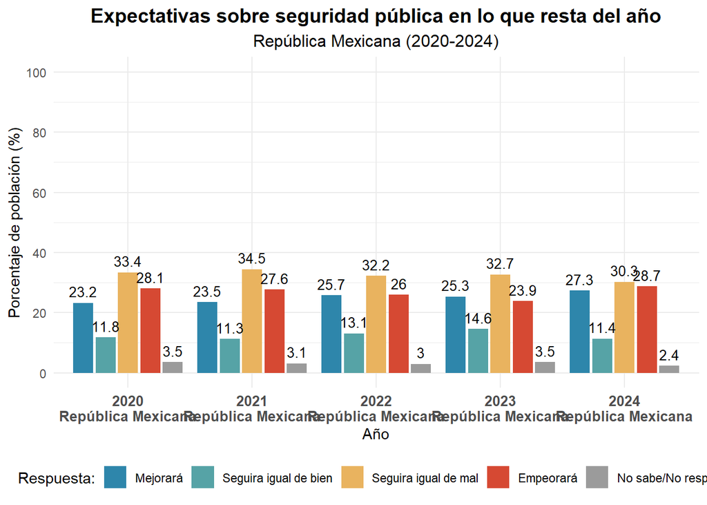

**Nota:** Cabe recalcar que dichos datos representan la opinion de los ciudadanos de la Republica Mexicana respecto a la seguridad publica en su estado, no respecto a la seguridad en la Republica Mexicana en general

**Análisis:**

Entre 2020 y 2024, el porcentaje de quienes creen que la situación mejorará muestra una tendencia ascendente: comienza en 23,2%, sube de forma casi continua hasta alcanzar 27,3% al final del periodo, con un leve descenso en 2023 (25,3%). La opción “seguirá igual de bien” aumenta hasta 14,6% en 2023, pero baja a 11,4% en 2024. “Seguirá igual de mal” se mantiene como la categoría más alta, aunque disminuye gradualmente desde 33,4% hasta 30,3%. Por su parte, “empeorará” desciende hasta 23,9% en 2023 y luego sube a 28,7% en 2024. El “no sabe/no responde” se mantiene en niveles bajos, siempre por debajo de 3,5%.

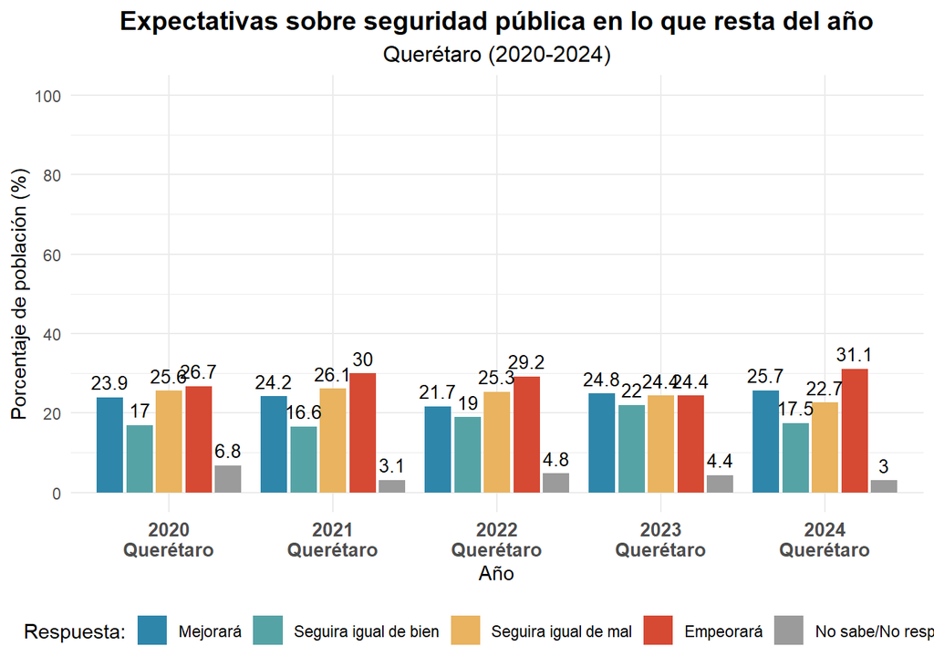

**Análisis:**

En Querétaro, la percepción de que la situación mejorará pasa de 23,9% en 2020 a 25,7% en 2024, con altibajos intermedios (destaca una caída a 21,7% en 2022). “Seguirá igual de bien” alcanza su punto más alto en 2023 con 22%, para después descender a 17,5%. “Seguirá igual de mal” se reduce de forma sostenida desde 25,6% hasta 22,7%. La categoría “empeorará” muestra un comportamiento errático: sube a 30% en 2021, baja a 24,4% en 2023, y termina en 31,1% en 2024, su valor más alto del periodo. El porcentaje de “no sabe/no responde” disminuye desde 6,8% hasta 3%.

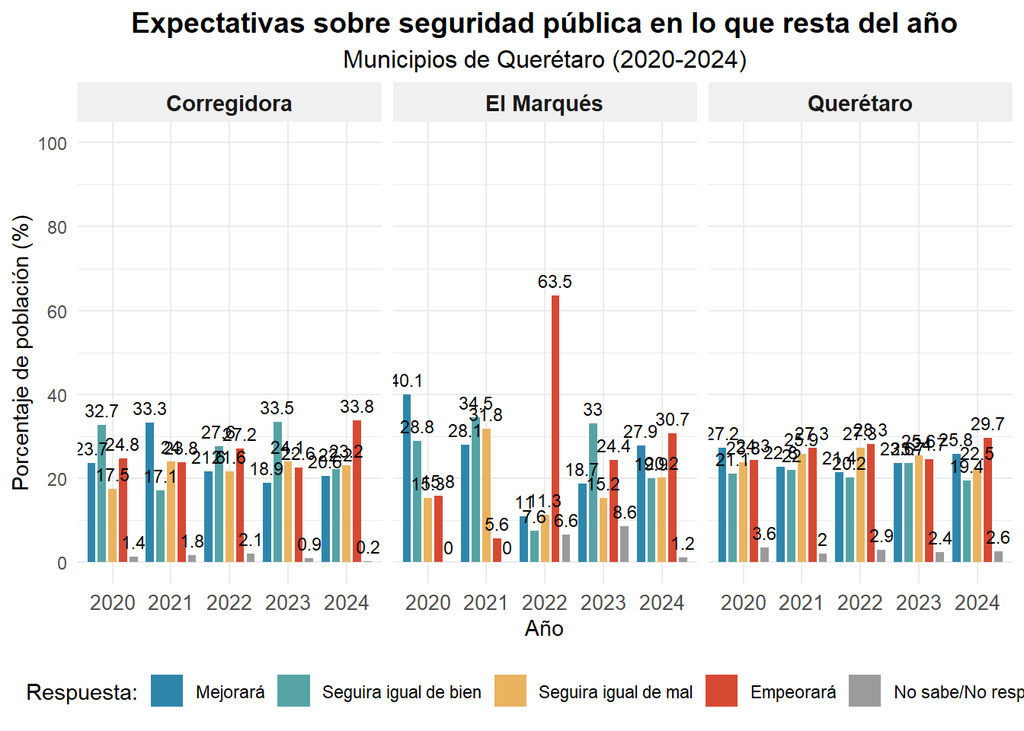

**Nota:** Los datos expuestos en la gráfica correspondiente a el municipio de El Marqués anteriores al año 2024 no representan con exactitud la información esperada, esto debido a la muestra tomada para el ENVIPE en sus ediciones 2021, 2022, 2023 y 2024, donde si bien El Marqués se considera una Área Urbana de Interés existe una diferencia abismal en el número de datos recopilados en estos años a los recopilados en 2025, pasando de una a once localidades principales para la alta de datos, lo que para los años anteriores a la ENVIPE 2025 significa menos cantidad de datos y a su vez anomalías al aplicar su factor de expansión correspondiente.

**Análisis:**

En El Marqués, “mejorará” cae de manera pronunciada desde 40,1% en 2020 hasta 11% en 2022, para luego recuperarse hasta 27,9% en 2024. “Seguirá igual de bien” presenta grandes variaciones (28,8%, 34,5%, 7,6%, 33%, 19,9%). “Seguirá igual de mal” tiene datos incompletos, pero se observa un pico de 31,8% en 2021. “Empeorará” registra un aumento extremo en 2022 (63,5%), aunque después baja a 30,7% en 2024.

**Conclusiones:**

En los tres niveles analizados, las percepciones sobre el futuro muestran trayectorias desiguales. La categoría “seguirá igual de mal” tiende a disminuir con el tiempo en la mayoría de los casos, aunque sigue siendo relevante. “Mejorará” presenta aumentos moderados en la República y en Querétaro estado, pero con comportamientos más irregulares a nivel municipal. “Empeorará” alcanza sus picos más altos en los municipios, especialmente en El Marqués y Corregidora al final del periodo. En conjunto, no hay una tendencia única: mientras que a nivel agregado se observa una ligera mejora en la expectativa de cambio positivo, en los municipios predominan las fluctuaciones fuertes y los incrementos de la percepción de empeoramiento en los últimos años.

### Pregunta 2: Problemas de robos en la localidad durante el año.

Esta pregunta analiza si la población ha percibido o experimentado problemas relacionados con robos en la localidad donde habita durante el transcurso del año. Específicamente, se pregunta a los encuestados: *En lo que va del año, ¿han presentado problemas de robos en la localidad en la que habita?*

Opciones de respuesta:

- Sí
- No
- No aplica
- No sabe/No responde

**¿Por qué es importante esta pregunta?**

La presencia de robos en una comunidad es uno de los principales indicadores de percepción de inseguridad y victimización social, ya que estos delitos afectan directamente la tranquilidad y calidad de vida de la población.

Esta pregunta permite:

- Identificar el nivel de incidencia percibida de robos en las localidades
- Analizar el impacto de la delincuencia en la vida cotidiana de las personas
- Evaluar cambios en la percepción de seguridad entre distintos años
- Detectar zonas o periodos con mayor sensación de vulnerabilidad social
- Relacionar la percepción ciudadana con las estrategias de seguridad implementadas

Las gráficas presentadas a continuación representan el porcentaje de personas que respondieron “Sí”, indicando que en su localidad sí se han presentado problemas de robos durante el año en curso.

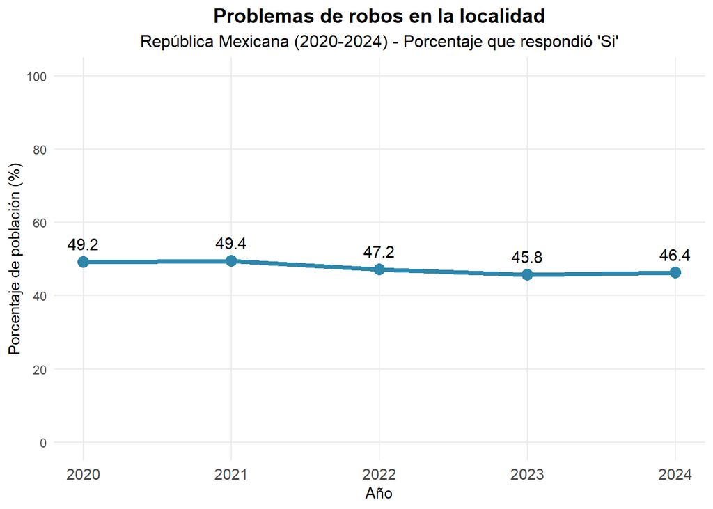

**Análisis:**

Entre 2021 y 2023 se observa una disminución sostenida del porcentaje, desde 49,4% hasta 45,8%, lo que supone una reducción de casi 4 puntos en dos años. En 2024 el valor asciende a 46,4%, aunque sin alcanzar el nivel inicial de 2020 (49,2%). El dato final es inferior al del inicio del periodo.

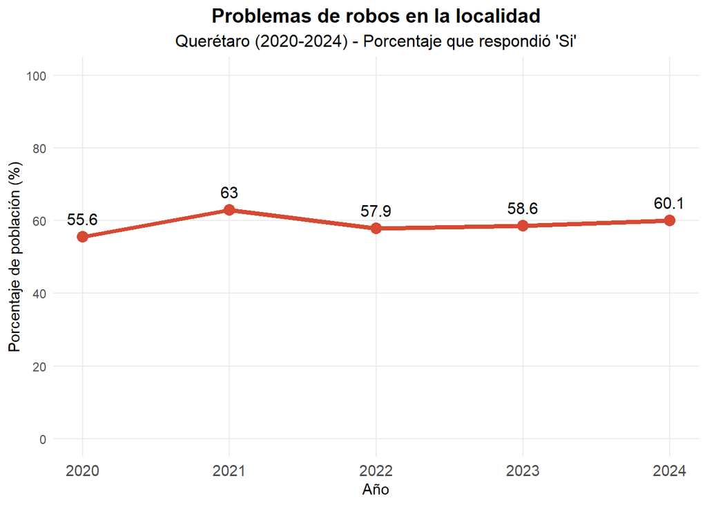

**Análisis:**

Se produce un aumento entre 2020 y 2021, alcanzando un punto máximo de 63,0%. En 2022 desciende a 57,9%, y desde ese año hasta 2024 se registra un incremento constante, pasando de 57,9% a 60,1%. Al cierre del periodo, el porcentaje final es 4,5 puntos superior al de 2020.

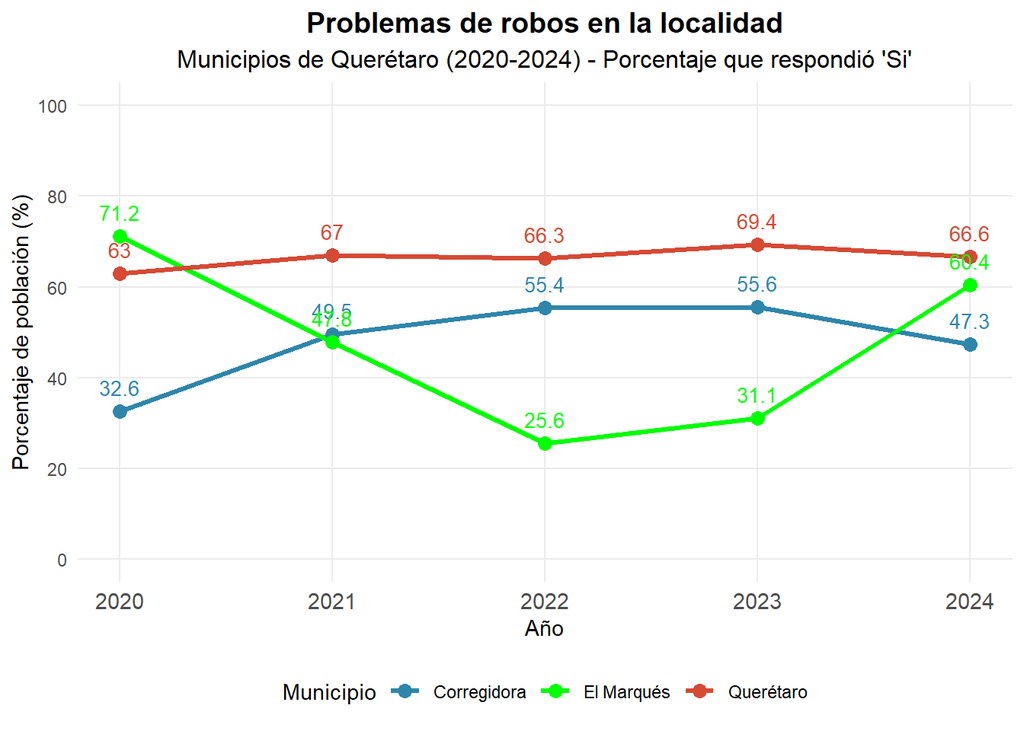

**Nota:** Los datos expuestos en la gráfica correspondiente a el municipio de El Marqués anteriores al año 2024 no representan con exactitud la información esperada, esto debido a la muestra tomada para el ENVIPE en sus ediciones 2021, 2022, 2023 y 2024, donde si bien El Marqués se considera una Área Urbana de Interés existe una diferencia abismal en el número de datos recopilados en estos años a los recopilados en 2025, pasando de una a once localidades principales para la alta de datos, lo que para los años anteriores a la ENVIPE 2025 significa menos cantidad de datos y a su vez anomalías al aplicar su factor de expansión correspondiente.

**Análisis:**

En Corregidora el porcentaje sube de 32,6% en 2020 a 55,6% en 2023, pero en 2024 baja a 47,3%.

En El Marqués parte de 71,2% en 2020, desciende hasta 25,6% en 2022, y luego aumenta hasta 60,4% en 2024.

En Querétaro los valores se mantienen con variaciones pequeñas: comienza en 63% en 2020, sube a 67% en 2021, y cierra en 66,6% en 2024.

### Pregunta 3: Tiempo de residencia en la vivienda.

Esta pregunta analiza el tiempo que las personas han permanecido viviendo en su vivienda actual, con el fin de identificar posibles relaciones entre estabilidad residencial, arraigo comunitario y percepción de seguridad. Específicamente, se pregunta a los encuestados: *¿Cuánto tiempo lleva viviendo en esta vivienda?*

Opciones de respuesta:

- Menos de seis meses
- Entre seis meses y un año
- Más de un año
- No sabe/No responde

**¿Por qué es importante esta pregunta?**

El tiempo de permanencia en una vivienda puede relacionarse directamente con la percepción de seguridad y el impacto de la delincuencia en la vida de las personas. En muchos casos, la inseguridad, los robos o la violencia provocan cambios constantes de residencia, debilitando el sentido de pertenencia y la confianza hacia la comunidad.

Esta pregunta permite:

- Analizar el nivel de estabilidad residencial de la población
- Relacionar la movilidad de las personas con problemas de inseguridad o delincuencia
- Identificar posibles efectos del miedo al delito en las decisiones de vivienda
- Comprender cómo el arraigo comunitario puede influir en la percepción de seguridad
- Evaluar si las personas que llevan más tiempo en una localidad presentan diferentes niveles de confianza o percepción del entorno

Las gráficas presentadas a continuación representan la distribución porcentual de las respuestas sobre el tiempo que las personas han vivido en su vivienda actual, permitiendo observar posibles cambios en la estabilidad residencial de la población a lo largo de los años.

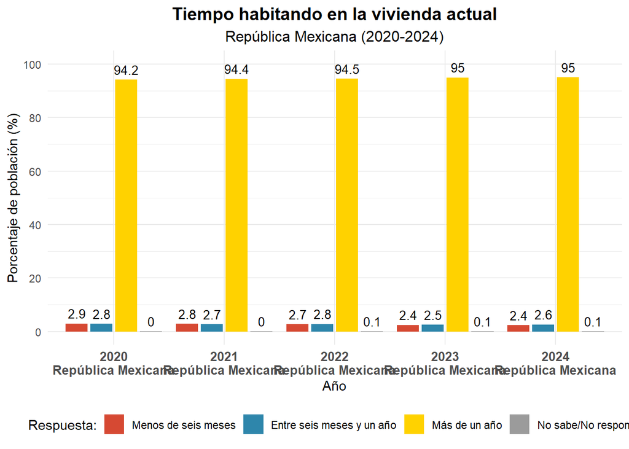

**Análisis:**

La gráfica nacional muestra que, durante todo el periodo 2020–2024, la gran mayoría de la población en México llevaba viviendo más de un año en su vivienda actual. En todos los años analizados, alrededor del 94% al 95% de las personas respondieron esta opción. Esto indica que la movilidad residencial en el país fue relativamente baja y que la mayoría de los hogares permanecieron estables en el mismo lugar. También se observa que el porcentaje de personas con menos de seis meses en la vivienda se mantuvo cercano al 2% o 3%, al igual del porcentaje de personas que llevaban entre seis meses y un año En conjunto, la gráfica refleja una situación de estabilidad habitacional a nivel nacional, sin cambios importantes entre un año y otro.

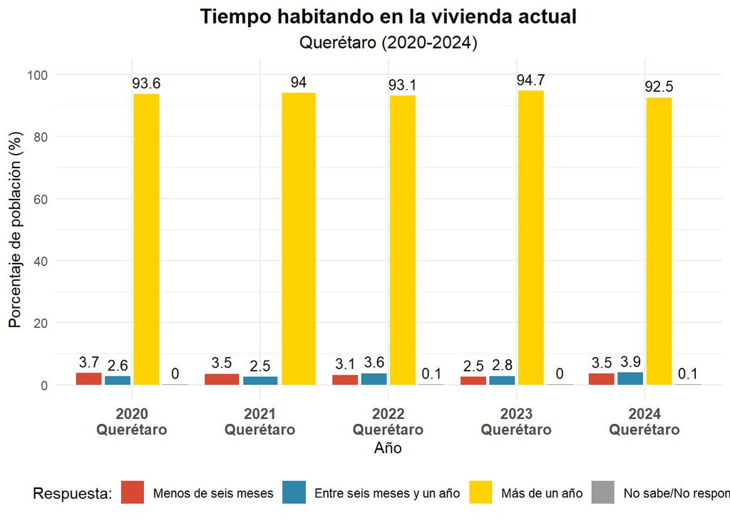

**Análisis:**

En el caso de Querétaro, el comportamiento fue muy parecido al observado a nivel nacional. La mayoría de la población también reportó haber vivido más de un año en su vivienda actual, con porcentajes que oscilaron entre 92% y 95% durante el periodo analizado. Sin embargo, se pueden notar algunas diferencias respecto al promedio nacional:

- Querétaro presentó porcentajes ligeramente mayores de personas con menos de un año habitando la vivienda.
- En 2024 se observa una pequeña disminución en el porcentaje de personas con más de un año en la vivienda (92.5%), acompañada de un aumento en quienes llevaban menos tiempo viviendo ahí.
- Esto podría relacionarse con el crecimiento urbano y poblacional del estado, así como con la llegada de nuevas personas por motivos laborales, educativos o de vivienda. Aun así, los datos muestran que la estabilidad residencial sigue siendo predominante en el estado.

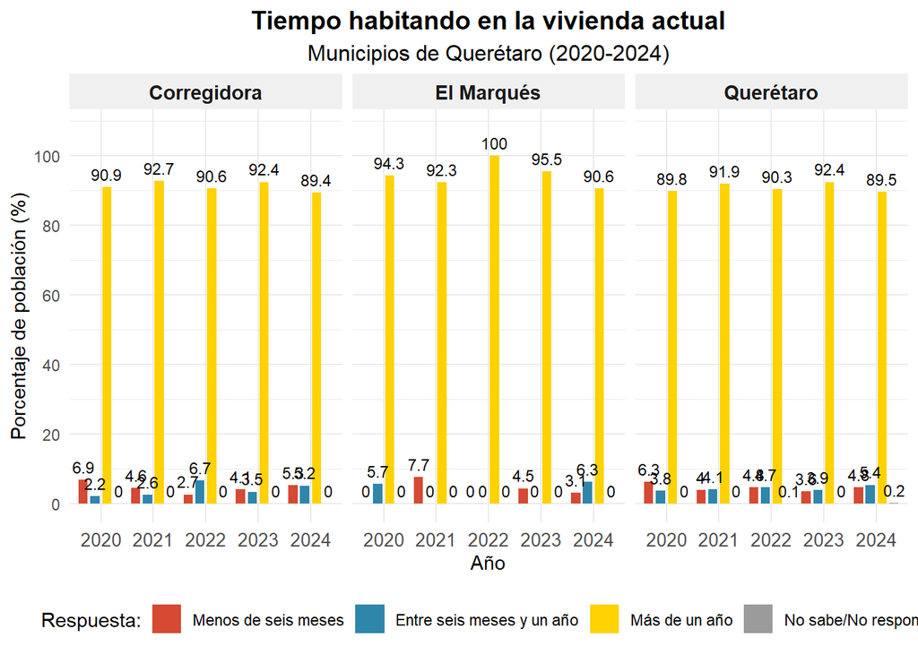

**Nota:** Los datos expuestos en la gráfica correspondiente a el municipio de El Marqués anteriores al año 2024 no representan con exactitud la información esperada, esto debido a la muestra tomada para el ENVIPE en sus ediciones 2021, 2022, 2023 y 2024, donde si bien El Marqués se considera una Área Urbana de Interés existe una diferencia abismal en el número de datos recopilados en estos años a los recopilados en 2025, pasando de una a once localidades principales para la alta de datos, lo que para los años anteriores a la ENVIPE 2025 significa menos cantidad de datos y a su vez anomalías al aplicar su factor de expansión correspondiente.

**Análisis:**

Corregidora mostró niveles altos y relativamente constantes de personas que llevaban más de un año viviendo en su hogar, generalmente alrededor del 90%. Sin embargo, también presentó algunos de los porcentajes más altos de personas con menos de seis meses en la vivienda, especialmente en 2020 y 2024. Esto puede sugerir una mayor movilidad residencial o crecimiento habitacional en el municipio.

**Conclusiones:**

Las tres gráficas muestran un patrón muy claro: tanto en México como en Querétaro y sus principales municipios, la mayoría de las personas ha permanecido más de un año en su vivienda.

Esto sugiere que:

- Existe una alta estabilidad residencial en la población.
- Los cambios frecuentes de vivienda son relativamente bajos.
- Querétaro mantiene un comportamiento similar al nacional, aunque con señales de mayor movilidad en algunos municipios.
- Corregidora y el municipio de Querétaro parecen tener una dinámica poblacional más activa, posiblemente relacionada con crecimiento urbano y llegada de nuevos habitantes.
- El Marqués mostró mayor estabilidad habitacional durante la mayor parte del periodo. En general, los resultados reflejan que la mayoría de los hogares mantienen una residencia estable y duradera en el lugar donde viven.

### Pregunta 4: Preocupación por la situación economica del país

La siguiente sección mide el nivel de la preocupación por la economía del país, para obtener estos resultados se pregunta al encuestado: *“De los temas que le voy a mostrar, ¿cuáles son los tres que le preocupan más?”*

Opciones de respuesta:

- Pobreza
- Desempleo
- Narcotráfico
- Aumento de precios
- Inseguridad
- Desastres naturales
- Escasez de agua
- Corrupción
- Educación
- Salud
- Falta de castigo a delincuentes
- Otro
- Ninguno
- No sabe / no responde

En la que se usaron las opciones de respuesta: Pobreza, Desempleo o Aumento de Precios. Si un ciudadano (mayor a 18 años) seleccionó dentro de sus respuestas alguna de las respuestas anteriormente, entonces se contará como parte de la población que siente preocupación por la economía. Posteriormente se hizo un resultado relativo de cuántas personas sentían este tipo de preocupación y la población que habita en su región política, ya sea alguna de las 32 entidades federativas o los 18 municipios del Estado de Querétaro, todo esto alrededor de los 5 años (2021-2025).

**¿Por qué es importante esta pregunta?**

La preocupación de la economía en la población puede servir como indicador económico sobre el país, principalmente en el rubro de la economía de hogar o familiar, ademas del bienestar economico de los ciudadanos de las diferentes zonas politicas analizadas por los siguientes graficos: país, estados, municipios

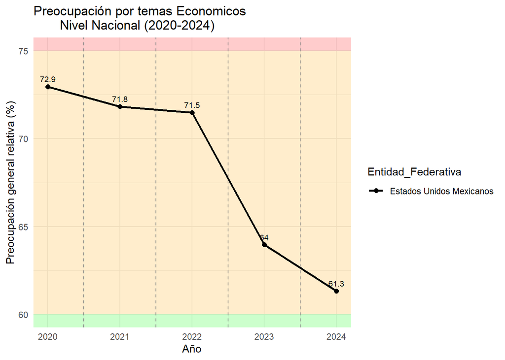

**Análisis:**

El nivel de preocupación sobre los rubros económicos mencionados ponderando a toda la nación ha bajado con el tiempo, pasando de un **73% en el 2021** a un **61% en el 2025**. Veremos que esta mejora no es igual en todas las partes del país, aunque mantiene la misma tendencia alrededor de todos los estados de la república.

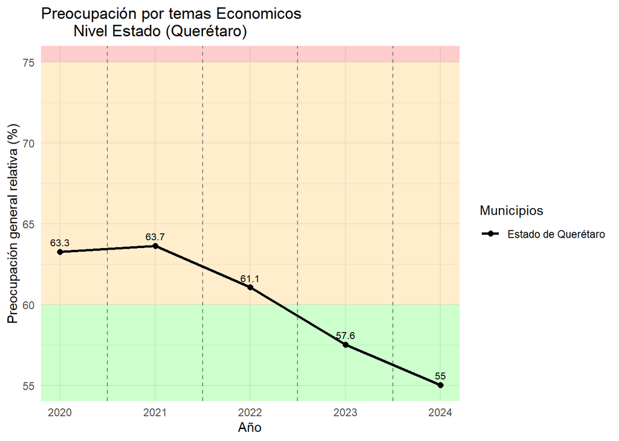

**Análisis:**

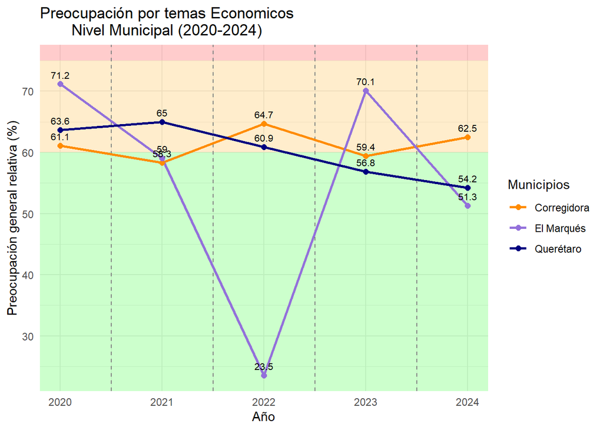

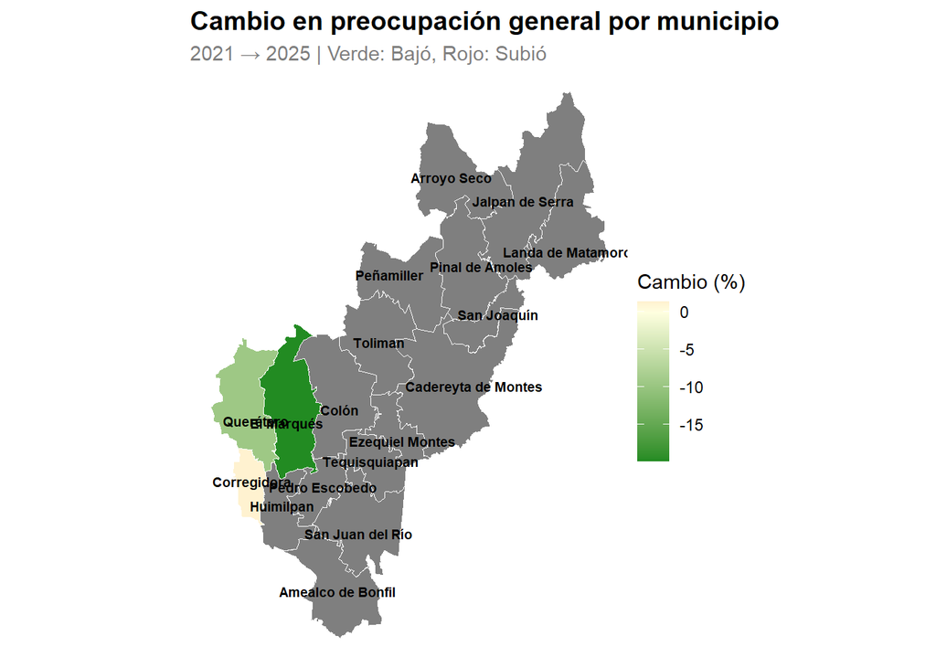

**Nota:** Los datos expuestos en la gráfica correspondiente a el municipio de El Marqués anteriores al año 2024 no representan con exactitud la información esperada, esto debido a la muestra tomada para el ENVIPE en sus ediciones 2021, 2022, 2023 y 2024, donde si bien El Marqués se considera una Área Urbana de Interés existe una diferencia abismal en el número de datos recopilados en estos años a los recopilados en 2025, pasando de una a once localidades principales para la alta de datos, lo que para los años anteriores a la ENVIPE 2025 significa menos cantidad de datos y a su vez anomalías al aplicar su factor de expansión correspondiente.

**Conclusiones:**

Se puede ver una tendencia muy clara en el país e incluso a nivel estatal en el estado de Querétaro, que esta preocupación entre la población mayor de edad a bajado con el tiempo, una de las razones puede ser que los picos más altos de preocupaciones fueron en el 2021 y 2022 años en que se tuvo problemas económicos debido a la pandemia, otra posible causa puede ser el aumento de otro tipo de preocupaciones en la población: como la delincuencia o la corrupción etc. Y que se seleccione otro tipo de respuesta, pero que aun se tenga una preocupación económica. Aunque la pregunta tenga que ver con el país, se ve claramente que los diferentes estados y municipios no tienen niveles similares de preocupación económica, por lo que se puede decir que esta pregunta mide la preocupación económica locamente, por eso los estados mas urbanos, industrializados o turísticos presentan menores niveles de preocupación económica como: Nuevo León o Ciudad de México. Y estados menos desarrollados presenten un mayor nivel de preocupación como: Chiapas, Veracruz, Tabasco, etc. A nivel estatal y municipal recalcar que la precisión de los datos va cayendo y que en la mayoría de municipios no se realizó esta encuesta.

### Pregunta 5: Delitos relacionado con vehículos

Este apartado analiza y compara la incidencia de los delitos relacionados con vehículos en el país, utilizando los microdatos de la **Encuesta Nacional de Victimización y Percepción sobre Seguridad Pública (ENVIPE)** para el periodo 2021-2025. El término **vehículos** corresponden exclusivamente a: *automóviles, camionetas y camiones*.

Para efectos de este análisis, los “delitos relacionados con vehículos” se segmentan en dos tipologías normativas:

- **Robo Total de Vehículo:** Se refiere al apoderamiento ilegal y con dolo de la unidad motriz completa, realizado sin el consentimiento de quien tiene el derecho legal de disponer de ella.
- **Robo Parcial de Vehículo:** Definido como un delito contra el patrimonio que consiste en el apoderamiento ilícito de partes, accesorios, refacciones o herramientas de un vehículo automotor.

**Enfoque en Delitos vs Víctimas:** Para este estudio se contabilizó estrictamente el número de delitos y no el número de víctimas. El diseño muestral de la ENVIPE registra el dato de victimización afectando a todo el hogar del propietario (lo que incluiría indirectamente a menores de 18 años).

La evaluación de la progresión temporal (2021-2025) se presenta bajo dos enfoques de cálculo según la división política (Nacional, Estatal y Municipal):

- **Análisis Absoluto:** Presentación del volumen o total neto de delitos vehiculares registrados por cada demarcación geográfica.
- **Análisis Relativo:** Indicador proporcional que calcula el número total de delitos vehiculares sobre el gran total de delitos cometidos en esa misma división política, permitiendo medir el peso específico de este delito en el ecosistema criminal local. Se pregunta a los encuestados:

*“¿Algún integrante de este hogar incluido usted, sufrieron la situación del grupo A?”*

Grupo A:

- Robo total de vehículo (automóvil, camioneta o camión)
- Robo de accesorios, refacciones o herramientas de vehículos (automóvil, camioneta, camión)
- Pinta de barda o grafiti en su casa, rayones o daños intencionales en su vehículo u otro tipo de vandalismo
- Alguien entró a su casa o departamento sin permiso mediante el uso de la fuerza o por engaños y robó o intentó robar algo

En esta pregunta se contabilizaron las primeras dos repuestas correspondientes al robo de autopartes/autos.

**¿Por qué es importante esta pregunta?**

Conocer si una persona ha sido víctima del robo parcial o total de un vehículo permite analizar uno de los delitos patrimoniales que más afectan la percepción de seguridad y la tranquilidad de la población. Además de representar pérdidas económicas, este tipo de delitos puede generar miedo, desconfianza y sensación de vulnerabilidad, por lo que su análisis ayuda a comprender el impacto de la delincuencia en la vida cotidiana y comparar su comportamiento a nivel nacional, estatal y municipal.

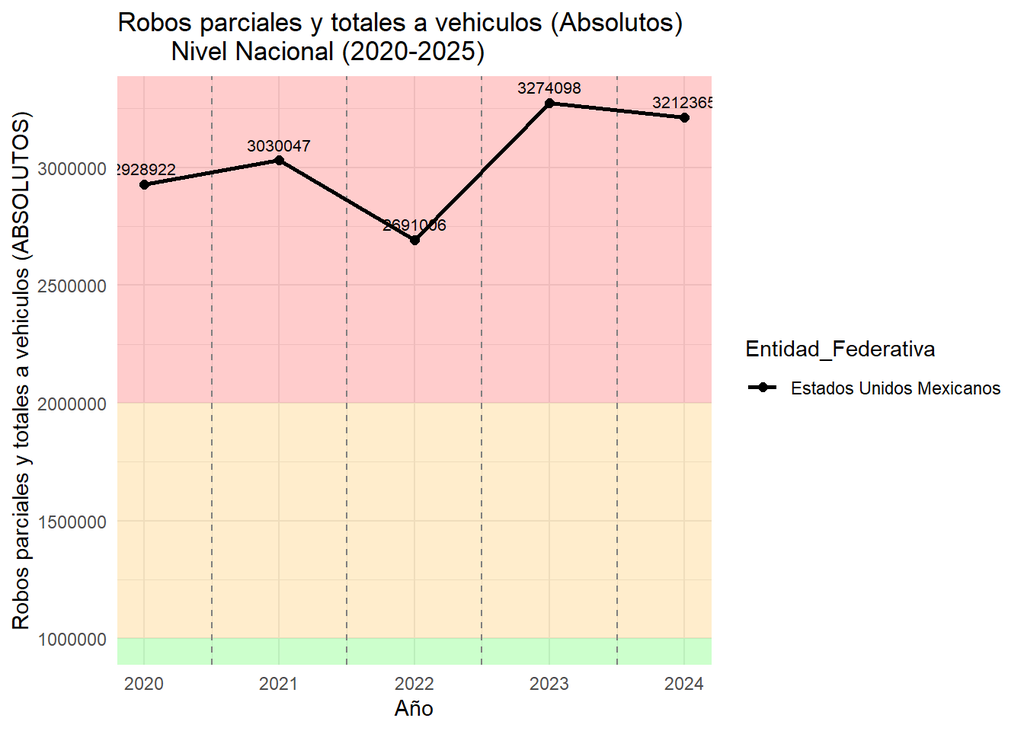

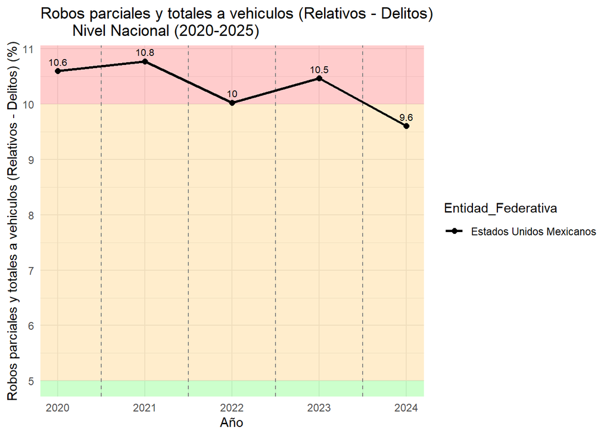

**Analisis:**

Las graficas anteriores miden la cantidad de delitos en el país, el primero de manera absoluta y el siguiente de manera relativa, cabe decir que de manera “relativa” se refiere al porcentaje de delitos referidos como “relacionado con vehículos” sobre el total de todos los delitos que ocurrieron en la República Mexicana, cabe mencionar que el número de delitos sobre vehículos subió hasta los 3,212,365 delitos a nivel país, pero la proporción de estos bajo con el tiempo, es decir los demás u otro tipo de delitos incrementaron con mayor fuerza en el tiempo que los delitos vehículares.

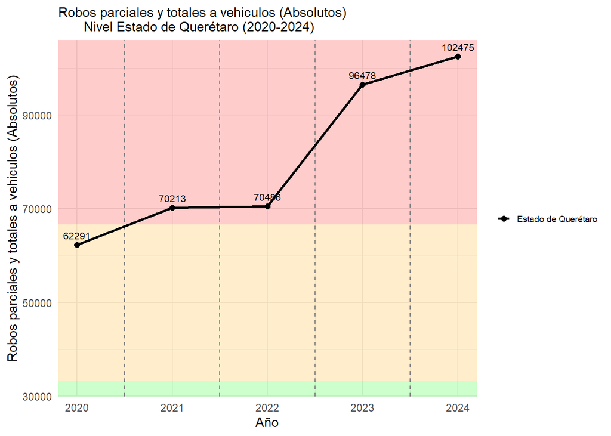

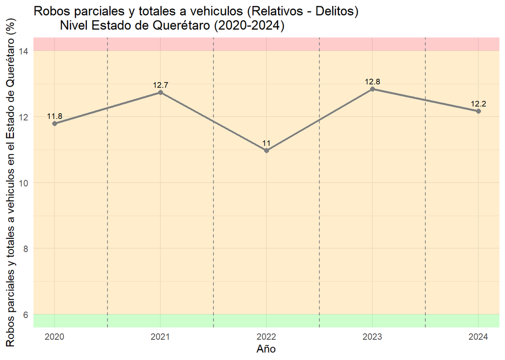

**Análisis:**

Los siguiente datos son exclusivos al estado de Querétaro, el primer gráfico muestra los delitos absolutos y el siguiente la proporción de estos sobre el total de delitos ocurridos en Querétaro. Se puede ver una tendencia a la alza en el número total de delitos relacionados a vehículos, en cambio no hay un incremento de la misma manera de la forma relativa, podría decirse que aunque aumenta los delitos de forma consistente la proporción respecto a otros delitos no lo hace.

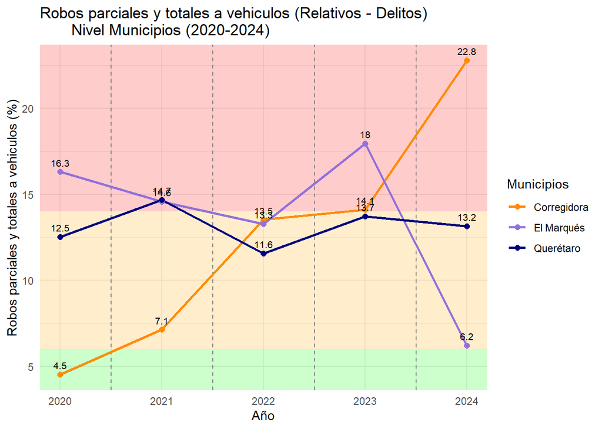

**Nota:** Los datos expuestos en la gráfica correspondiente a el municipio de El Marqués anteriores al año 2024 no representan con exactitud la información esperada, esto debido a la muestra tomada para el ENVIPE en sus ediciones 2021, 2022, 2023 y 2024, donde si bien El Marqués se considera una Área Urbana de Interés existe una diferencia abismal en el número de datos recopilados en estos años a los recopilados en 2025, pasando de una a once localidades principales para la alta de datos, lo que para los años anteriores a la ENVIPE 2025 significa menos cantidad de datos y a su vez anomalías al aplicar su factor de expansión correspondiente.

**Análisis:**

Posteriormente se muestra la progresión de los datos relativos, sobre los municipios encuestados, en esta comparativa se nota el crecimiento de los delitos vehículares en el estado de Corregidora, pasando a representar un 4.5% de los delitos en 2020 a representar el 22.78% de los delitos en el 2024. Aun así se nota Corregidora no representa demasiado en la tendencia general del estado.

**Conclusiones:**

Señalar que el número de delitos de esta índole fueron en aumento alrededor de todo el país, especialmente en el estado de Querétaro pero su proporción con los demás delitos no, incluso hasta esta bajaba como lo es el caso a nivel nacional, esto podria indicar que otros tipos de delitos aumentan con mayor fuerza que el delito analizado anteriormente. A nivel municipal se excluyeron los datos de aquellos municipios en los que no se realizo encuesta de manera directa ya que muestran datos imprecisos o inexistentes en varios años, pero dichos datos si fueron incluidos al nivel estatal (Querétaro) ya que esas encuestas se realizaron en territorio Querétano.

### Pregunta 6: Sobre secuestros convencionales y exprés.

Este apartado analiza la evolución y el comportamiento de los delitos de secuestro y secuestro exprés en el país durante el periodo **2020-2024**.

Estos datos contienen restricciones limitantes al generar un dato cercano a la realidad ya que son fenómenos con baja frecuencia muestral, aun con esto el seguimiento de este indicador es fundamental debido a su severo impacto en el tejido social y en la construcción de la percepción de inseguridad ciudadana. Acerca de esto el INEGI declara:

Aunque en la ENVIPE se explora el secuestro en los delitos personales, este es un fenómeno escaso desde el punto de vista de una medición probabilística y, por tanto, representa dificultades para generar estimaciones con calidad estadística. Sin embargo, es importante contar con una medida sobre el mismo, ya que impacta profundamente en la percepción de la población sobre la seguridad pública.

Por lo tanto, si bien los volúmenes totales pueden presentar imprecisiones respecto a la cifra real, la homogeneidad metodológica mantenida por el INEGI a lo largo del periodo analizado (2020-2024) permite identificar de manera confiable las tendencias y la progresión temporal del fenómeno.

**Definiciones:**

**Secuestro (Convencional):** Consiste en la privación ilegal de la libertad cuya duración se extiende desde un día completo hasta días, semanas o meses.

**Secuestro Exprés:** Corresponde a toda privación de la libertad que haya durado **menos de 24 horas**. Generalmente, la retención se prolonga por pocas horas con propósitos de beneficio inmediato, tales como el saqueo de cuentas bancarias en cajeros automáticos, la exigencia de rescates rápidos en efectivo o el despojo del vehículo automotor.

La evaluación de los datos se estructuró bajo dos enfoques complementarios para cada división política (Nacional, Estatal y Municipal):

1. Análisis Absoluto
2. Análisis Relativo (Tasa de Incidencia - Tasa de secuestros por cada 100,000 habitantes)

A los encuestados se les pregunta: *¿Algún integrante de este hogar incluido usted, sufrió un secuestro o secuestro exprés, para exigir dinero o bienes?*

Opciones de respuesta:

- Si
- No
- No sabe / No responde

En este reporte se uso la respuesta “Si” para realizar las gráficas y datos.

**¿Por qué es importante esta pregunta?**

**Medición del Impacto Social Devastador:** El secuestro es uno de los delitos que genera mayor impacto psicológico y social, destruyendo la sensación de seguridad no solo de la víctima directa, sino de su núcleo familiar y comunitario.

**Indicador Clave de Percepción de Inseguridad:** Existe una correlación directa entre el temor al secuestro y la adopción de medidas extremas de autocuidado por parte de la ciudadanía (como cambiar rutinas, evitar salir de noche o modificar rutas habituales).

**Consistencia en el Análisis de Tendencias:** Al mantenerse la misma metodología de captura por parte del INEGI durante el periodo analizado, el indicador funciona como un termómetro institucional útil para observar si el problema se está conteniendo o agravando en el tiempo.

**Visibilización de la Cifra Negra:** Permite contrastar de manera orientativa la prevalencia estimada por la encuesta frente a las denuncias formales ante el Ministerio Público, evidenciando el nivel de subregistro de este delito de alto impacto.

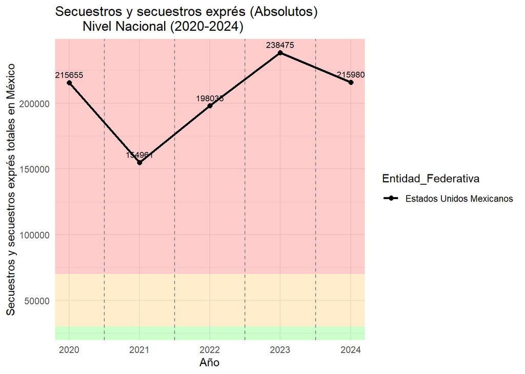

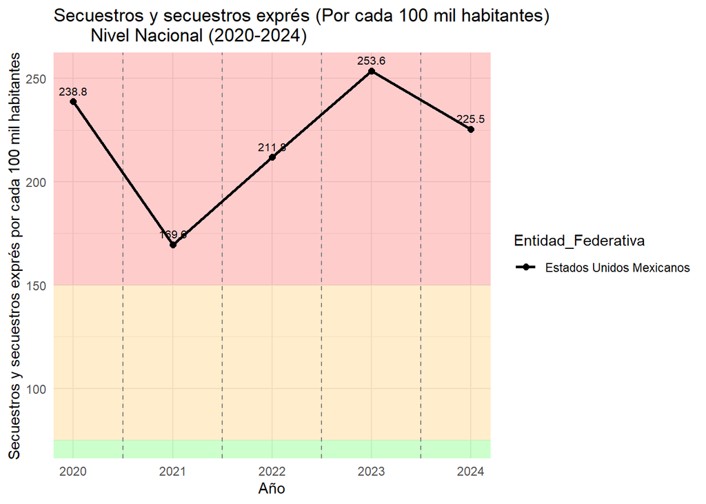

**Análisis:**

A nivel nacional la cantidad de secuestros absolutos se mantiene con el tiempo partiendo con 215,655 secuestros en 2020 a pasar a 215,980 en 2024, teniendo el pico en el año 2023 con 238,475 secuestros. Por lo tanto en siguiente gráfica se tiene una ligera caída en la cantidad de delitos por cada 100 mil habitantes, de 238 secuestros por cada 100 mil habitantes en 2020 a tener 225 secuestros por 100 mil habitantes en 2024.

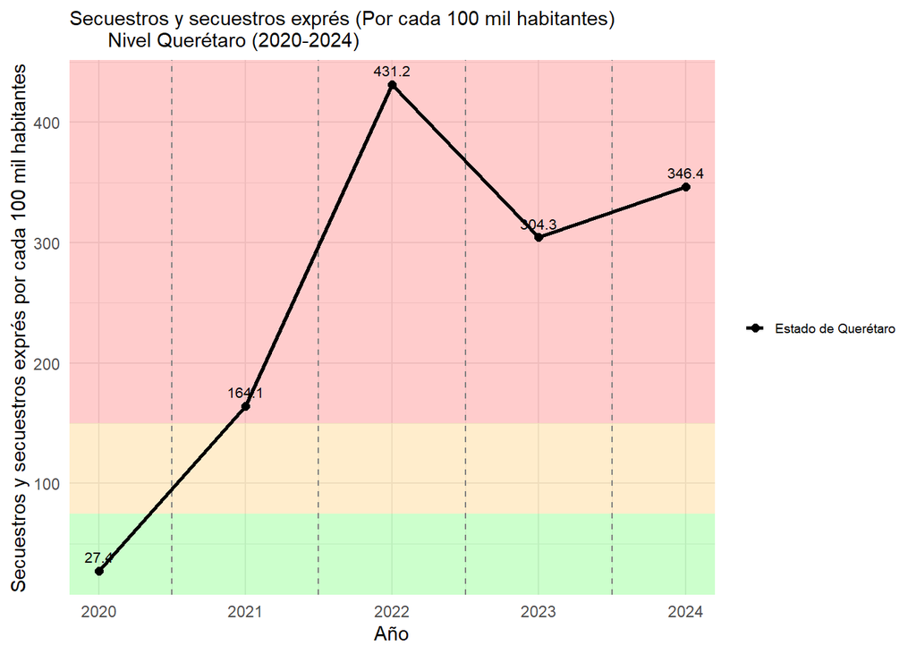

**Análisis:**

**Conclusiones:**

Como se dijo el número de secuestros no tiene que ser relevante, sino el comportamiento de los datos a lo largo del tiempo, tomando esto en cuenta vemos que a mivel pais la progresión es casi “plana” el crecimiento y el decrecimiento de los secuestros se ha estancado a nivel nacional, no se puede decir lo mismo del estado de Querétaro que ha aumentado el número de secuestros en el estado durante 2020-2025, volver a recalcar que aunque los municipios en los que se hace la encuesta en el estado de Querétaro (El Marqués, Corregidora y Querétaro) no tengan datos en algunos años, existen datos a nivel estatal ya que si se contabilizan los datos de otros municipios excluidos ya que conforman a la totalidad del estado de Querétaro.

### Pregunta 7: Conocimiento sobre operativos contra la delincuencia en las localidades.

Esta sección analiza el nivel de conocimiento y familiaridad que tiene la población respecto a las acciones de las corporaciones de seguridad pública en su entorno local. A los encuestados se les pregunta: *¿Sabe usted si alguna de las siguientes acciones se realizó en su localidad, operativos contra la delincuencia?*

Opciones de respuesta:

- Si sabe
- No sabe
- No se realizó
- No responde

Para las siguientes gráficas, se utilizo la respuesta “si sabe” en la opción “operativos contra la delincuencia?”, esta parte tiene como objetivo ver como las autoridades de seguridad pública han hecho su labor, intentando desmantelar de manera organizada la delincuencia de las localidades analizadas (país, estados, municipios). La manera de analizar los datos es de manera relativa, es decir: la cantidad de personas que dijeron que “si supieron acerca de operativos contra la delincuencia” sobre la población total de la localidad.

**¿Por qué es importante esta pregunta?**

El conocimiento ciudadano sobre las acciones de la autoridad es un pilar fundamental para evaluar la efectividad de las políticas de seguridad en el territorio. Esta pregunta permite:

**Evaluar el despliegue institucional:** Funciona como un indicador directo de la presencia proactiva y el patrullaje visible de las corporaciones en las calles.

**Medir el impacto de la disuasión:** Ayuda a entender si las estrategias diseñadas para desmantelar de manera organizada a la delincuencia están logrando su objetivo de hacerse notar ante la población.

**Contrastar la percepción con la realidad operativa:** Permite analizar si un incremento en el presupuesto o en el número de operativos en zonas prioritarias (como las zonas metropolitanas) realmente se traduce en una mayor notoriedad para los ciudadanos de a pie.

**Vincular la presencia con la confianza:** Sirve de base para estudiar si la visibilidad de los operativos genera un sentimiento de respaldo y tranquilidad en la comunidad o si, por el contrario, pasa desapercibida.

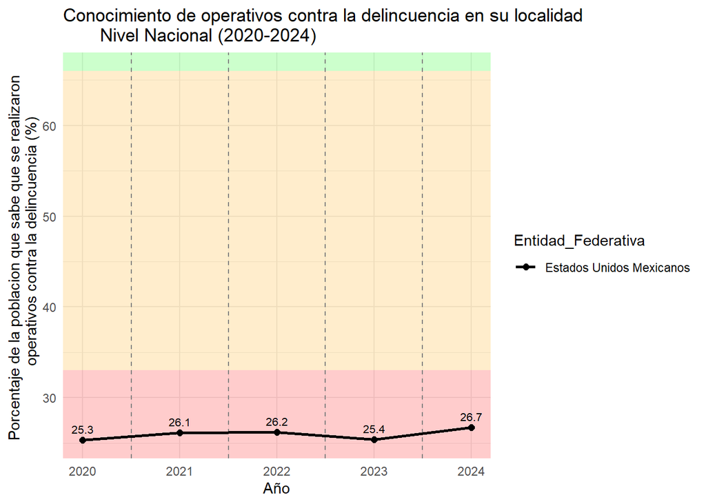

**Análisis:**

De manera nacional es minoría la cantidad de personas que tuvieron conocimiento de operativos en contra de la delincuencia en su localidad, no superando el 27% de la población a nivel nacional en ninguno de los años entre 2020-2024, cabe mencionar que no es conocimiento de operativos a nivel nacional, sino operativos a nivel local.

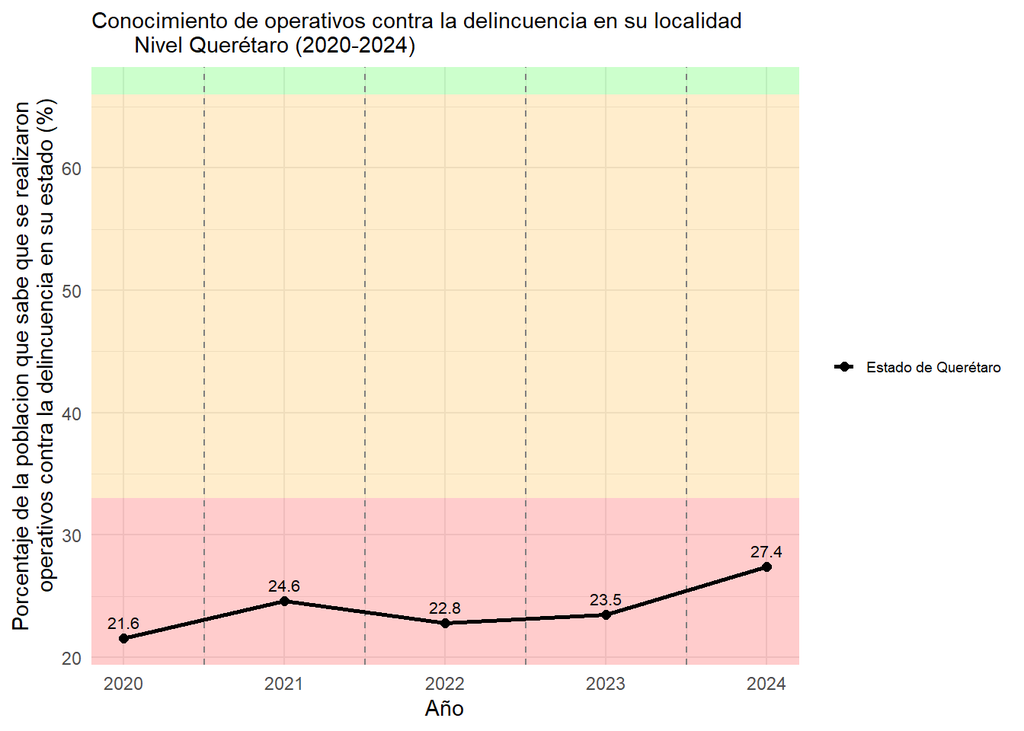

**Análisis:**

En el estado de Querétaro se ve una pequeña tendencia a la alza en el que la población del estado sepa mas sobre estos acontecimientos de seguridad pública. Aunque aun manteniendo una pequeña parte de la población con conocimiento de este tipo de operativos contra la delincuencia, teniendo un 21% en 2020 a un 27,3% en 2024 de la población con conocimiento de estas medidas por parte de las instituciones de seguridad pública, siendo el ultimo año 2024 el pico de población.

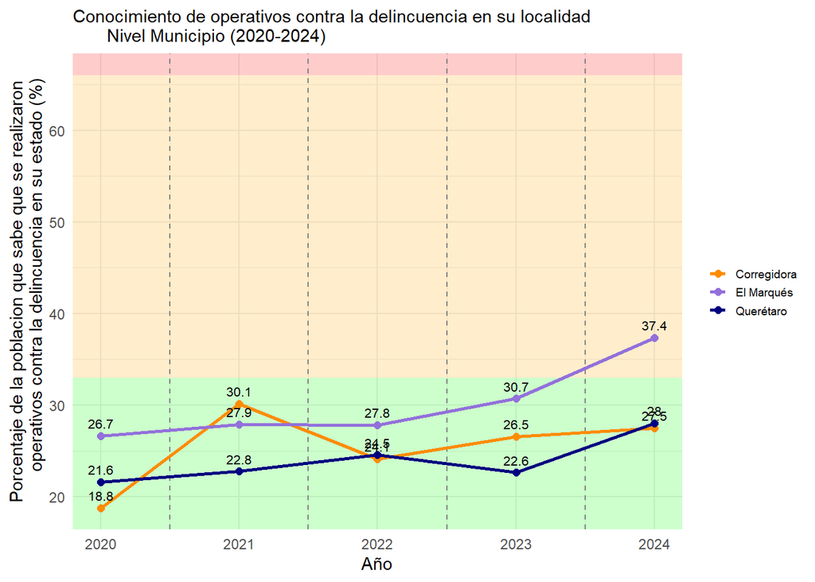

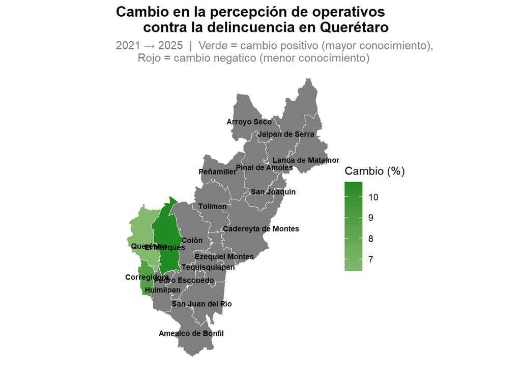

**Nota:** Los datos expuestos en la gráfica correspondiente a el municipio de El Marqués anteriores al año 2024 no representan con exactitud la información esperada, esto debido a la muestra tomada para el ENVIPE en sus ediciones 2021, 2022, 2023 y 2024, donde si bien El Marqués se considera una Área Urbana de Interés existe una diferencia abismal en el número de datos recopilados en estos años a los recopilados en 2025, pasando de una a once localidades principales para la alta de datos, lo que para los años anteriores a la ENVIPE 2025 significa menos cantidad de datos y a su vez anomalías al aplicar su factor de expansión correspondiente.

**Análisis**

En el estrato municipal se encuentra la siguiente gráfica que muestra la tendencia a la alza en los municipios. Posteriormente se muestra el mapa de cambio, es decir que tanto ha cambiado la proporción de población con conocimiento de estos operativos entre el 2020 al 2024.

**Conclusiones**

Recalcar que al ser una pregunta fuera del contexto de victimazación se obtienen mejores datos en el estrato municipal del estado de Querétaro, también ver que la tendencia a nivel nacional es ligeramente a la alza, en cambio a nivel municipal en el estado de Querétaro es la tendencia se hace más grande en municipios puntuales, también decir que esta pregunta no refleja el nivel de delincuencia en los estados y municipios analizados, sino el conocimiento general de la población sobre estos de manera local, podría existir una correlación entre la cantidad de operativos que las autoridades han realizada en las respectivas entidades políticas analizadas con los datos obtenidos obtenidos, pero eso solo es una suposición.

### Pregunta 8: Desaparición forzada por autoridad o grupo delictivo

La desaparición forzada es uno de los problemas más graves relacionados con la seguridad y los derechos humanos. Este fenómeno (aquí “fenómeno” se usará como una forma general de decir: “el problema o situación de desaparición forzada”, no significa algo raro o misterioso) ocurre cuando una persona desaparece de manera involuntaria y existen indicios de participación de autoridades o grupos delictivos.

Se pregunta a los encuestados: *¿Algún(a) integrante de este hogar desapareció de manera forzada o en contra de su voluntad, por la acción de una autoridad o un grupo delictivo?*

Opciones de respuesta:

- Sí
- No
- No sabe / no responde

**¿Por qué es importante esta pregunta?**

La pregunta es importante porque permite conocer si los hogares han vivido experiencias relacionadas con este tipo de violencia y cómo evoluciona el problema a lo largo del tiempo.

Además, la información ayuda a identificar diferencias entre entidades y municipios, así como cambios en la percepción y reporte de estos hechos.

La siguiente gráfica muestra el resultado a nivel nacional del porcentaje de población que respondió “sí”:

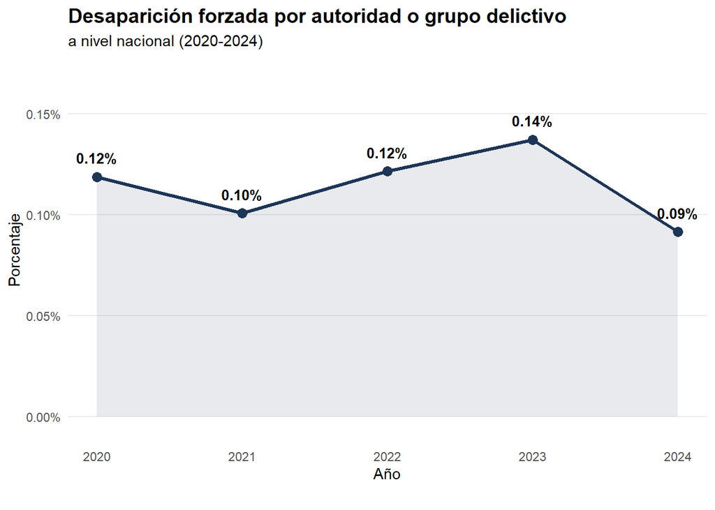

**Análisis**

A nivel nacional, la proporción de población afectada por desaparición forzada se mantuvo en niveles bajos entre 2020 y 2024, oscilando entre aproximadamente 0,09% y 0,14% y la gráfica muestra un comportamiento relativamente estable, aunque con algunas pequeñas variaciones.

El incremento registrado entre 2021 y 2023 podría indicar una mayor visibilidad o reporte del fenómeno en ciertos periodos. Sin embargo, debido a que los porcentajes son muy bajos, la presencia constante de casos a lo largo de todos los años indica que se trata de un problema que continúa existiendo.

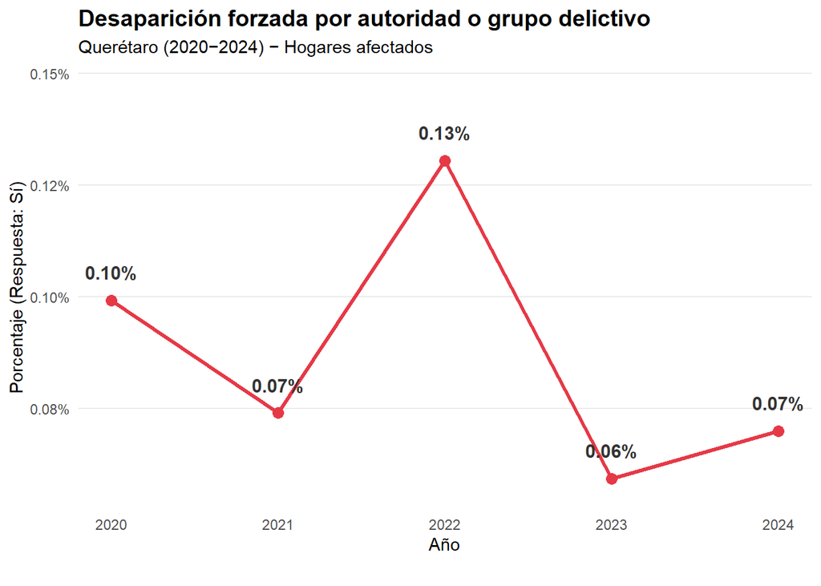

**Análisis**

La gráfica muestra que la proporción de hogares en Querétaro que reportaron haber sufrido desaparición forzada se mantuvo en niveles muy bajos entre 2020 y 2024, lo que indica que se trata de un fenómeno estadísticamente poco frecuente dentro de la población encuestada.

A pesar de los bajos niveles observados, puede identificarse cierta variabilidad a través de los años. Sin embargo, la tendencia general sugiere estabilidad en niveles bajos, sin evidencia de un crecimiento sostenido.

En términos comparativos, los resultados estatales muestran un comportamiento similar al observado a nivel nacional: niveles bajos y fluctuaciones moderadas sin una tendencia claramente creciente o decreciente. Esto sugiere que el fenómeno se mantiene relativamente estable dentro del período estudiado, aunque continúa siendo un tema de alta relevancia social por la gravedad de los hechos asociados a la desaparición forzada.

[figure not shown]

**Análisis**

Durante todo el periodo analizado, el porcentaje de hogares afectados fue muy bajo, siempre por debajo del 0.5%. En términos generales, la gráfica refleja estabilidad en el comportamiento de este indicador durante el periodo 2020–2024.

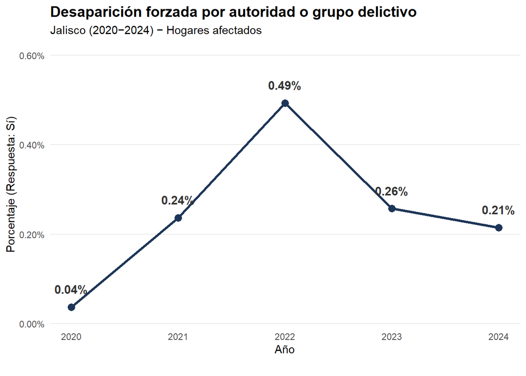

**Análisis de Jalisco**

A diferencia de Querétaro y del promedio nacional Jalisco presenta niveles superiores durante casi todo el periodo analizado. Particularmente en 2022, el porcentaje registrado en Jalisco fue mayor que el observado a nivel estatal en Querétaro y a nivel nacional. Esto podría estar relacionado con una mayor percepción, visibilidad o reporte del fenómeno, una mayor disposición de las personas a reportarlo en la encuesta o diferencias en las dinámicas regionales de violencia y criminalidad.

No obstante, aunque los porcentajes siguen siendo bajos en términos absolutos, el crecimiento observado entre 2020 y 2022 resulta relevante por la magnitud relativa del incremento. Mientras en 2020 el indicador era cercano a 0.04%, para 2022 alcanzó casi medio punto porcentual, lo que representa un aumento considerable dentro de la serie histórica analizada.

Asimismo, debe considerarse que la desaparición forzada es un fenómeno altamente sensible. Factores como el miedo, la desconfianza hacia las autoridades o la falta de denuncia pueden influir en las respuestas de las personas encuestadas, por lo que los resultados deben interpretarse como aproximaciones estadísticas derivadas de la ENVIPE.

**Comparación entre Jalisco y Querétaro**

La diferencia más notable ocurrió en 2022. Ese año, Querétaro registró alrededor de 0.13%, mientras que Jalisco alcanzó aproximadamente 0.49%, es decir, casi cuatro veces más. Incluso en los años posteriores, cuando los porcentajes de Jalisco disminuyeron, continuaron ubicándose por encima de los valores observados en Querétaro.

Además de presentar niveles más altos, los porcentajes de Jalisco cambiaron bruscamente entre un año y otro. Querétaro, en cambio, mantuvo fluctuaciones moderadas y además en niveles bajos.

**Conclusiones**

Los resultados de la ENVIPE muestran que la desaparición forzada reportada por los hogares se mantuvo en niveles bajos entre 2020 y 2024 tanto a nivel nacional como en Querétaro. Sin embargo, el hecho de que el fenómeno siga apareciendo de forma constante en la encuesta refleja que continúa siendo un tema sensible y de gran importancia social.

Querétaro presentó porcentajes relativamente estables y menores que los observados en Jalisco, mientras que esta última entidad mostró incrementos más notorios, especialmente en 2022. Esto evidencia que la situación no afecta de la misma manera a todas las regiones del país.

También es importante considerar que, debido al miedo o a la desconfianza, la desaparición forzada puede tener menos reportes de los que en realidad son. Por ello, los resultados deben entenderse como una aproximación estadística sobre un fenómeno y delicado.

### Pregunta 9: ¿Cuánta confianza tiene la población mexicana en sus amigos?

Esta pregunta analiza el nivel de confianza interpersonal que las personas tienen hacia sus amigos, con el fin de identificar posibles relaciones entre convivencia social, percepción de apoyo comunitario y efectos sociales de la inseguridad. Específicamente, se pregunta a los encuestados: *Dígame el grado de confianza que tiene en amigos.*

Opciones de respuesta:

- Mucha
- Alguna
- Poca
- Nada
- No aplica
- No sabe / no responde

**¿Por qué es importante esta pregunta?**

La confianza entre personas es un elemento fundamental para la convivencia social. Tener confianza en amigos y personas cercanas puede relacionarse con redes de apoyo, bienestar emocional y sensación de seguridad en la vida cotidiana.Por ello, analizar este indicador permite conocer cómo percibe la población sus relaciones personales y qué tan fuertes son los vínculos sociales dentro de una comunidad.

Las siguientes gráficas muestran el nivel de confianza que tienen las personas en sus amigos entre 2020 y 2024, tanto en el estado de Querétaro como en todo México. También se incluye una comparación entre municipios de Querétaro.

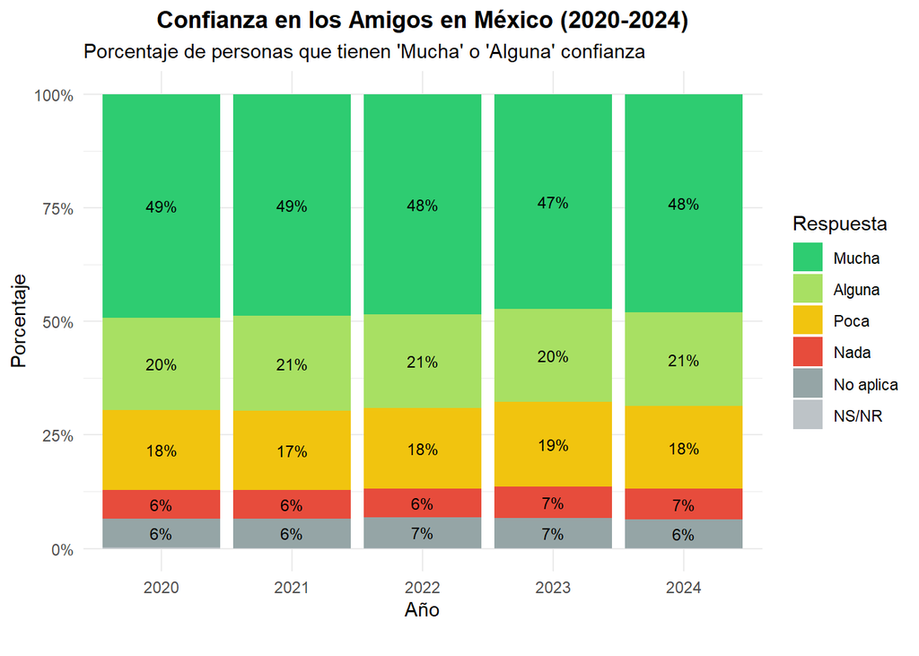

**Análisis**

La gráfica nacional muestra que la mayoría de las personas en México tiene una percepción positiva sobre sus amistades. Durante todo el periodo analizado, las respuestas de “mucha” y “alguna” confianza concentraron la mayor parte de la población.

Además, los resultados se mantuvieron muy estables entre 2020 y 2024, lo que sugiere que las relaciones de amistad continúan siendo una fuente importante de apoyo social para gran parte de la población mexicana.

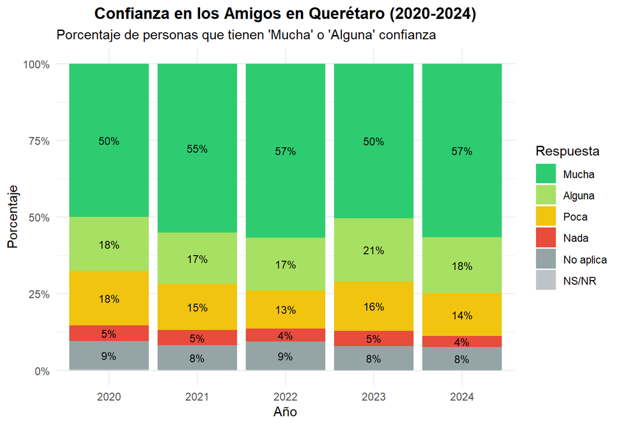

**Análisis**

La gráfica de Querétaro muestra que la mayoría de las personas tienen una opinión positiva sobre sus amigos.

También se observa que:

- La confianza se mantuvo relativamente estable entre 2020 y 2024.
- El porcentaje de personas con “mucha” confianza aumentó ligeramente en 2024.
- Las respuestas negativas (“poca” o “nada” de confianza) fueron menores y cambiaron poco con el tiempo.

En general, los resultados sugieren que las relaciones de amistad en Querétaro se perciben como fuertes y confiables.

Al comparar Querétaro con el promedio nacional, se puede observar que Querétaro presenta niveles de confianza ligeramente más altos.

Por ejemplo: